# eindproject

Cynthia de Nijs

20 mei 2017

```r
library(caret)
```

```r
library(corrplot)
library(rpart)
library(rpart)
library(randomForest)
library(parallel)
library(doParallel)
library(ggplot2)
library(lattice)
```

### project course 8

class-variabele voorspellen schrijf een rapport over hoe je het model hebt gebouwd hoe je cross validation hebt gebruikt wat je denkt dat de out of sample error is waarom heb je de keuzes gemaakt die je hebt gemaakt.

Data

The training data for this project are available here:

https://d396qusza40orc.cloudfront.net/predmachlearn/pml-training.csv

The test data are available here:

https://d396qusza40orc.cloudfront.net/predmachlearn/pml-testing.csv

The data for this project come from this source: http://groupware.les.inf.puc-rio.br/har. If you use the document you create for this class for any purpose please cite them as they have been very generous in allowing their data to be used for this kind of assignment.

What you should submit

The goal of your project is to predict the manner in which they did the exercise. This is the “classe” variable in the training set. You may use any of the other variables to predict with. You should create a report describing how you built your model, how you used cross validation, what you think the expected out of sample error is, and why you made the choices you did. You will also use your prediction model to predict 20 different test cases.

Peer Review Portion

Your submission for the Peer Review portion should consist of a link to a Github repo with your R markdown and compiled HTML file describing your analysis. Please constrain the text of the writeup to < 2000 words and the number of figures to be less than 5. It will make it easier for the graders if you submit a repo with a gh-pages branch so the HTML page can be viewed online (and you always want to make it easy on graders :-).

Course Project Prediction Quiz Portion

Apply your machine learning algorithm to the 20 test cases available in the test data above and submit your predictions in appropriate format to the Course Project Prediction Quiz for automated grading.

Reproducibility

Due to security concerns with the exchange of R code, your code will not be run during the evaluation by your classmates. Please be sure that if they download the repo, they will be able to view the compiled HTML version of your analysis.

# read the data and replace “NA”, “#DIV/0!”, “” by NA (160 columns)

```r
training <- read.csv(url("https://d396qusza40orc.cloudfront.net/predmachlearn/pml-training.csv"), na.strings=c("NA","#DIV/0!", ""))
testing <- read.csv(url("https://d396qusza40orc.cloudfront.net/predmachlearn/pml-testing.csv"),  na.strings=c("NA","#DIV/0!", ""))
```

# cleaning data

remove NA-columns (60 columns left) remove columns that will not explain the outcome variable: X, user_name, raw_timestamp_part_1, raw_timestamp_part_2, cvdt_timestamp, new_window, num_window (53 columns left)

```r
training <- training[,colSums(is.na(training))==0]
testing <- testing[,colSums(is.na(testing))==0]

training <- training[,-c(1:7)]
testing <- testing[,-c(1:7)]
```

# split the data

I split the trainingsset in a testset and a trainingset (train). The dataset isn’t big and isn’t small so the trainingsset contains 60% of the data and the testset 40%.

```r
set.seed(123)
inTrain <- createDataPartition(y=training$classe, p = 0.60, list=FALSE)
train <- training[inTrain,]
test <- training[-inTrain,]
dim(train)
```

```
## [1] 11776    53
```

```r
dim(test)
```

```
## [1] 7846   53
```

# explore the data

balance in outcomes? yes!

```r
table(train$classe)
```

```
##
##    A    B    C    D    E
## 3348 2279 2054 1930 2165
```

near zero variable; there are no near zero var. left

```r
nzv <- nearZeroVar(train, saveMetrics=TRUE)
nzv
```

```
##                      freqRatio percentUnique zeroVar   nzv
## roll_belt             1.099812    8.49184783   FALSE FALSE
## pitch_belt            1.196078   13.88417120   FALSE FALSE
## yaw_belt              1.049536   14.60597826   FALSE FALSE
## total_accel_belt      1.062878    0.22927989   FALSE FALSE
## gyros_belt_x          1.071871    1.08695652   FALSE FALSE
## gyros_belt_y          1.140443    0.55197011   FALSE FALSE
## gyros_belt_z          1.043315    1.35869565   FALSE FALSE
## accel_belt_x          1.098684    1.35020380   FALSE FALSE
## accel_belt_y          1.105946    1.12941576   FALSE FALSE
## accel_belt_z          1.090038    2.43716033   FALSE FALSE
## magnet_belt_x         1.076555    2.54755435   FALSE FALSE
## magnet_belt_y         1.069588    2.39470109   FALSE FALSE
## magnet_belt_z         1.003413    3.63451087   FALSE FALSE
## roll_arm             49.926829   19.45482337   FALSE FALSE
## pitch_arm            75.814815   22.60529891   FALSE FALSE
## yaw_arm              29.242857   21.45040761   FALSE FALSE
## total_accel_arm       1.093458    0.55197011   FALSE FALSE
## gyros_arm_x           1.119205    5.23097826   FALSE FALSE
## gyros_arm_y           1.512987    3.05706522   FALSE FALSE
## gyros_arm_z           1.162500    1.98709239   FALSE FALSE
## accel_arm_x           1.009524    6.45380435   FALSE FALSE
## accel_arm_y           1.171642    4.40726902   FALSE FALSE
## accel_arm_z           1.052632    6.44531250   FALSE FALSE
## magnet_arm_x          1.019231   11.11582880   FALSE FALSE
## magnet_arm_y          1.055556    7.14164402   FALSE FALSE
## magnet_arm_z          1.125000   10.54687500   FALSE FALSE
## roll_dumbbell         1.219178   87.21127717   FALSE FALSE
## pitch_dumbbell        2.134831   85.02887228   FALSE FALSE
## yaw_dumbbell          1.219178   86.65930707   FALSE FALSE
## total_accel_dumbbell  1.102689    0.36514946   FALSE FALSE
## gyros_dumbbell_x      1.013661    1.93614130   FALSE FALSE
## gyros_dumbbell_y      1.249300    2.25033967   FALSE FALSE
## gyros_dumbbell_z      1.002740    1.64741848   FALSE FALSE
## accel_dumbbell_x      1.036458    3.33729620   FALSE FALSE
## accel_dumbbell_y      1.006757    3.81283967   FALSE FALSE
## accel_dumbbell_z      1.036810    3.35427989   FALSE FALSE
## magnet_dumbbell_x     1.097087    8.71263587   FALSE FALSE
## magnet_dumbbell_y     1.278846    6.83593750   FALSE FALSE
## magnet_dumbbell_z     1.052632    5.53668478   FALSE FALSE
## roll_forearm         11.085308   14.70788043   FALSE FALSE
## pitch_forearm        66.828571   21.05129076   FALSE FALSE
## yaw_forearm          15.904762   14.22384511   FALSE FALSE
## total_accel_forearm   1.135099    0.56046196   FALSE FALSE
## gyros_forearm_x       1.060317    2.33525815   FALSE FALSE
## gyros_forearm_y       1.053333    6.05468750   FALSE FALSE
## gyros_forearm_z       1.090909    2.37771739   FALSE FALSE
## accel_forearm_x       1.034483    6.59816576   FALSE FALSE
## accel_forearm_y       1.080645    8.15217391   FALSE FALSE
## accel_forearm_z       1.032609    4.61107337   FALSE FALSE
## magnet_forearm_x      1.000000   12.07540761   FALSE FALSE
## magnet_forearm_y      1.142857   15.18342391   FALSE FALSE
## magnet_forearm_z      1.027027   13.44259511   FALSE FALSE
## classe                1.469065    0.04245924   FALSE FALSE
```

how about correlations/multicollinearity? : a lot of blue -> multicollinearity

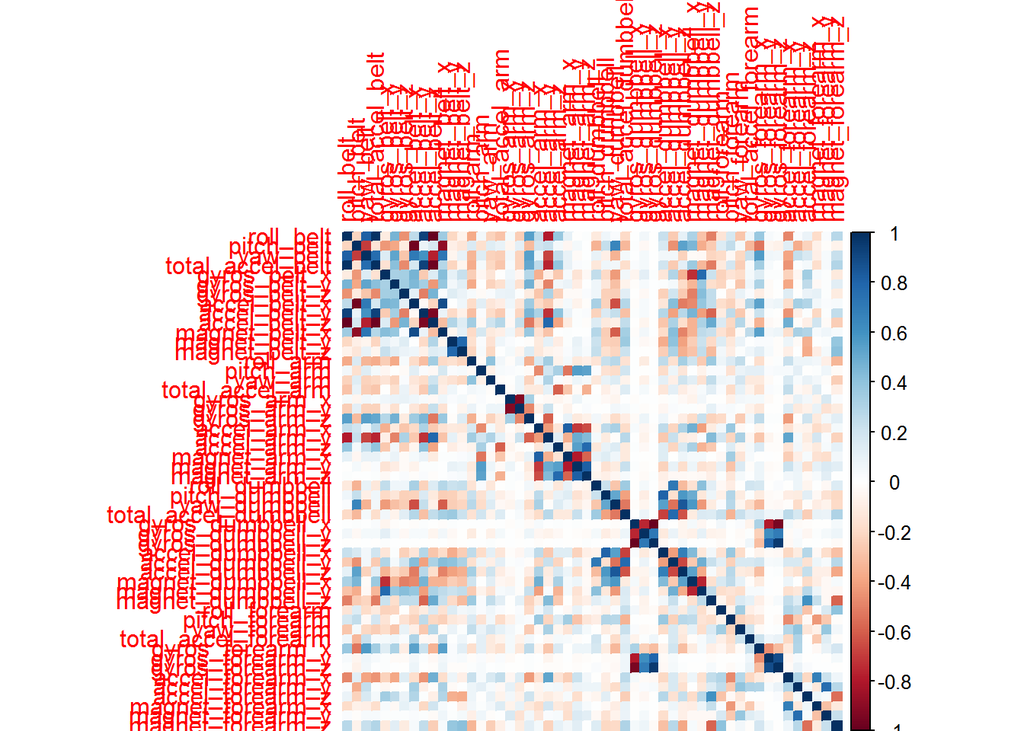

```r
corrplot(cor(train[,-53]), method="color")
```

let’s have a look at the first 13 rows

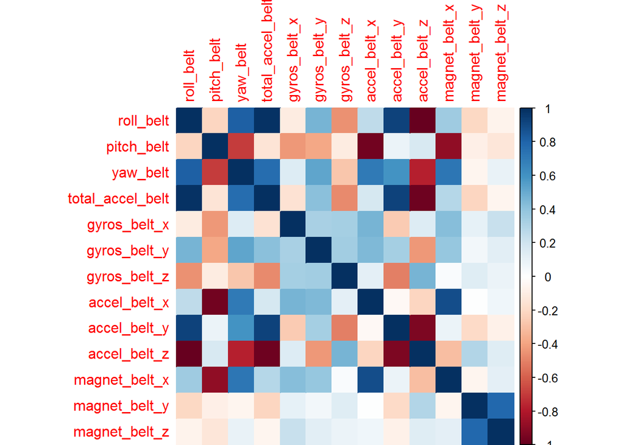

```r
corrplot(cor(train[,c(1:13)]), method="color")
```

# make a model

classification model: Tree. this model is not accurate (was aspected because of multicollinearity)

```r
modFitT <- train(classe ~ ., method = "rpart", data=train)
finModT <- modFitT$finalModel
print(modFitT)
```

```
## CART
##
## 11776 samples
##    52 predictor
##     5 classes: 'A', 'B', 'C', 'D', 'E'
##
## No pre-processing
## Resampling: Bootstrapped (25 reps)
## Summary of sample sizes: 11776, 11776, 11776, 11776, 11776, 11776, ...
## Resampling results across tuning parameters:
##
##   cp          Accuracy   Kappa
##   0.03998576  0.5024092  0.3534124
##   0.04224015  0.4757915  0.3104877
##   0.11722829  0.3238448  0.0598947
##
## Accuracy was used to select the optimal model using  the largest value.
## The final value used for the model was cp = 0.03998576.
```

# classification model: random forest

let’s try a random forest-model. This model can handle multicollinearity.

short discription: the random forest-model creates a lot of trees. Each tree is build on a different sample of the data (bootstrapping). A each node of the tree is using a random set of m variables that may contribute to the split. The trees are voted to predict an outcome.

Because it’s very slow we use clusters.

The chosen resampling method is cross validation (10-fold).

```r
set.seed(123)
cluster <- makeCluster(detectCores() - 1) # convention to leave 1 core for OS
registerDoParallel(cluster)


fitControl <- trainControl(method = "cv",
                           number = 10,
                           allowParallel = TRUE)

modFitRf <- train(classe ~ ., method = "rf", data=train, trControl=fitControl)

stopCluster(cluster)
registerDoSEQ()
```

confusionmatrix:

```r
finModRf <- modFitRf$finalModel
finModRf
```

```
##
## Call:
##  randomForest(x = x, y = y, mtry = param$mtry)
##                Type of random forest: classification
##                      Number of trees: 500
## No. of variables tried at each split: 2
##
##         OOB estimate of  error rate: 0.93%
## Confusion matrix:
##      A    B    C    D    E class.error
## A 3343    4    0    0    1 0.001493429
## B   16 2256    7    0    0 0.010092146
## C    0   30 2018    6    0 0.017526777
## D    1    0   38 1889    2 0.021243523
## E    0    0    1    4 2160 0.002309469
```

rf performs good and is accurate: 0,9907

```r
print(modFitRf)
```

```
## Random Forest
##
## 11776 samples
##    52 predictor
##     5 classes: 'A', 'B', 'C', 'D', 'E'
##
## No pre-processing
## Resampling: Cross-Validated (10 fold)
## Summary of sample sizes: 10599, 10599, 10598, 10598, 10599, 10598, ...
## Resampling results across tuning parameters:
##
##   mtry  Accuracy   Kappa
##    2    0.9906586  0.9881822
##   27    0.9904039  0.9878619
##   52    0.9846296  0.9805559
##
## Accuracy was used to select the optimal model using  the largest value.
## The final value used for the model was mtry = 2.
```

# out of sample error

the accuracy of the testset is 0,9916 (see the statistics) the out of sample error is 1-0,9916 =0,0084 the accuracy of the testset is (higer than)almost) the same as the accuracy of the train-set

```r
pred <- predict(modFitRf, test)
confusionMatrix(pred, test$classe)
```

```
## Confusion Matrix and Statistics
##
##           Reference
## Prediction    A    B    C    D    E
##          A 2228   11    0    0    0
##          B    4 1503   14    0    0
##          C    0    4 1354   26    2
##          D    0    0    0 1259    4
##          E    0    0    0    1 1436
##
## Overall Statistics
##
##                Accuracy : 0.9916
##                  95% CI : (0.9893, 0.9935)
##     No Information Rate : 0.2845
##     P-Value [Acc > NIR] : < 2.2e-16
##
##                   Kappa : 0.9894
##  Mcnemar's Test P-Value : NA
##
## Statistics by Class:
##
##                      Class: A Class: B Class: C Class: D Class: E
## Sensitivity            0.9982   0.9901   0.9898   0.9790   0.9958
## Specificity            0.9980   0.9972   0.9951   0.9994   0.9998
## Pos Pred Value         0.9951   0.9882   0.9769   0.9968   0.9993
## Neg Pred Value         0.9993   0.9976   0.9978   0.9959   0.9991
## Prevalence             0.2845   0.1935   0.1744   0.1639   0.1838
## Detection Rate         0.2840   0.1916   0.1726   0.1605   0.1830
## Detection Prevalence   0.2854   0.1939   0.1767   0.1610   0.1832
## Balanced Accuracy      0.9981   0.9936   0.9924   0.9892   0.9978
```

# the most important variables

```r
varImp(modFitRf)
```

```
## rf variable importance
##
##   only 20 most important variables shown (out of 52)
##
##                   Overall
## roll_belt          100.00
## yaw_belt            83.78
## magnet_dumbbell_z   71.57
## magnet_dumbbell_y   66.96
## pitch_belt          63.12
## pitch_forearm       60.77
## roll_forearm        55.62
## magnet_dumbbell_x   54.85
## accel_belt_z        51.07
## magnet_belt_z       47.16
## roll_dumbbell       46.54
## accel_dumbbell_y    46.09
## magnet_belt_y       44.91
## accel_dumbbell_z    38.68
## roll_arm            35.20
## accel_forearm_x     33.96
## gyros_dumbbell_y    31.58
## yaw_dumbbell        31.52
## accel_dumbbell_x    31.38
## magnet_arm_x        30.85
```

# now we predict on the testingset

```r
predT <- predict(modFitRf, testing)
predT
```

```
##  [1] B A B A A E D B A A B C B A E E A B B B
## Levels: A B C D E
```